# Project: Image Classification with CNNs(Conv2D) using the CIFAR-10 Dataset

## Goal

The goal of this project is to build a 2D Convolutional Neural Network (CNN) to classify images from the CIFAR-10 dataset into 10 categories. The aim is to achieve high accuracy while maintaining model efficiency and to demonstrate how Conv2D layers process spatial information in images.

## Motivation for the Project

Image classification is one of the fundamental tasks in computer vision and serves as a foundation for more advanced tasks like object detection and segmentation. The CIFAR-10 dataset provides a diverse collection of small-sized images, making it an excellent benchmark for beginners (like me and my team mate) to practice and evaluate image classification algorithms. Using Conv2D layers allows the model to extract spatial features such as edges, patterns, and textures, which are critical for image classification tasks.

# Description of the Data

The CIFAR-10 dataset is a dataset often used in machine learning, particularly for image classification tasks. It provides a standard, balanced dataset to evaluate the performance of different algorithms and models.

**Theoretical Background:**

**Dataset Overview:**

**Name:**

CIFAR-10 (**Canadian Institute for Advanced Research**) The CIFAR-10 dataset was introduced by Alex Krizhevsky, Geoffrey Hinton, and Vinod Nair in their research at the University of Toronto.

**Purpose:** Designed for training machine learning and deep learning models for image recognition.

**Structure:**

- Contains 60,000 images divided into:
- Training Set: 50,000 images.
- Test Set: 10,000 images.
- Images are color (RGB), 32x32 pixels, and divided into 10 classes.

**Classes:**

The dataset contains the following 10 classes:

- Airplane
- Automobile
- Bird
- Cat
- Deer
- Dog
- Frog
- Horse
- Ship
- Truck Each class has 6,000 images.

**References:**

**Official Reference:** CIFAR-10 Website

**Where we got our data:** CIFAR-10 Dataset on Kaggle

After the above description, i will start by importing the necessary libraries

## Implementation

### Install Required Libraries

```python
import tensorflow as tf
from tensorflow.keras.datasets import cifar10
import matplotlib.pyplot as plt
from tensorflow.keras.models import Sequential
from tensorflow.keras.layers import Conv2D, MaxPooling2D, Flatten, Dense, Dropout
```

### Load dataset

```python
# Load CIFAR-10 dataset
(x_train, y_train), (x_test, y_test) = cifar10.load_data()
(x_train, y_train), (x_test, y_test)
```

[output not shown]

[output cut: 573 more lines]

[output not shown]

## Data Exploration

```python
x_train.shape
```

```
(50000, 32, 32, 3)
```

```python
x_test.shape
```

```
(10000, 32, 32, 3)
```

```python
y_train.shape
```

```
(50000, 1)
```

```python
y_test.shape
```

```
(10000, 1)
```

```python
y_train[:5]
```

```
array([[6],
       [9],
       [9],
       [4],
       [1]], dtype=uint8)
```

```python
#we see that y_train[:5] is a 2dimensional array so i will first convert it to a 1dimensional array before futher exploring my data
```

```python
y_train=y_train.reshape(-1,)
y_train
```

```
array([6, 9, 9, ..., 9, 1, 1], dtype=uint8)
```

## Display some sample images with labels

**Here are classes in the dataset as well as 10 random images from each:**

[figure not shown]

```python
import matplotlib.pyplot as plt
import numpy as np
from tensorflow.keras.datasets import cifar10

# Load the CIFAR-10 dataset
(x_train, y_train), (x_test, y_test) = cifar10.load_data()

# Class labels for CIFAR-10
class_labels = ['Airplane', 'Automobile', 'Bird', 'Cat', 'Deer', 'Dog', 'Frog', 'Horse', 'Ship', 'Truck']

# Function to display images with class labels in the first column
def plot_cifar10_with_labels(x, y, class_labels):
    plt.figure(figsize=(15, 15))
    num_classes = len(class_labels)
    images_per_class = 10  # Number of images per class
    for i, class_label in enumerate(class_labels):
        # Select images belonging to the current class
        class_indices = np.where(y.flatten() == i)[0]
        selected_indices = class_indices[:images_per_class]

        for j, idx in enumerate(selected_indices):
            # Compute grid position
            row = i
            col = j + 1  # Shift by one to leave the first column for labels

            # Add the image to the grid
            plt.subplot(num_classes, images_per_class + 1, row * (images_per_class + 1) + col + 1)
            plt.imshow(x[idx])
            plt.axis('off')

        # Add class label in the first column
        plt.subplot(num_classes, images_per_class + 1, row * (images_per_class + 1) + 1)
        plt.text(0.5, 0.5, class_label, fontsize=12, ha='center', va='center')
        plt.axis('off')

    plt.tight_layout()
    plt.show()

# Plot the images with class labels in the first column
plot_cifar10_with_labels(x_train, y_train, class_labels)
```

**Key Characteristics:**

- Each image is 32x32 pixels in size, making it a relatively low-resolution dataset.
- Images are in color (RGB), with 3 channels (Red, Green, Blue).

```python
#testing index to ge class name
class_names[9]
```

```
'Truck'
```

```python
# Flatten the labels array
y_flat = y_train.flatten()  # This converts y from a 2D array to a 1D array

# Use y_flat instead of y to access class labels
def plot_sample(x, y, index):
    plt.figure(figsize=(15, 2))
    plt.imshow(x[index])
    plt.xlabel(class_labels[y[index]])  # Access the class label with the flattened array
    plt.show()
```

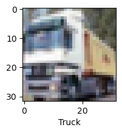

```python
# Example usage
plot_sample(x_train, y_train.flatten(), 1)  # Flatten y_train when calling the function
```

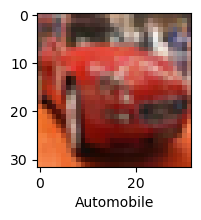

```python
plot_sample(x_train,y_train,5)
```

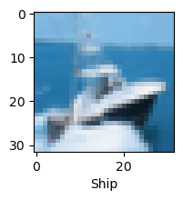

```python
plot_sample(x_train,y_train,8)
```

### Data Preparation

```python
# Normalize the data
x_train = x_train.astype('float32') / 255.0
x_test = x_test.astype('float32') / 255.0
```

### Building the CNN Model

```python
from tensorflow.keras.utils import to_categorical

# Convert labels to one-hot encoding
y_train = to_categorical(y_train, 10)
y_test = to_categorical(y_test, 10)
```

```python
# Build the CNN model
model = Sequential([
    # First Conv2D block
    Conv2D(32, (3, 3), activation='relu', input_shape=(32, 32, 3)),
    MaxPooling2D((2, 2)),

    # Second Conv2D block
    Conv2D(64, (3, 3), activation='relu'),
    MaxPooling2D((2, 2)),

    # Third Conv2D block
    Conv2D(128, (3, 3), activation='relu'),
    MaxPooling2D((2, 2)),

    # Fully connected layers
    Flatten(),
    Dense(128, activation='relu'),
    Dropout(0.5),
    Dense(10, activation='softmax')  # Output layer for 10 classes
])

# Compile the model
model.compile(optimizer='adam',
              loss='categorical_crossentropy',
              metrics=['accuracy'])

model.summary()
```

```
Model: "sequential_4"
```

```
┏━━━━━━━━━━━━━━━━━━━━━━━━━━━━━━━━━━━━━━┳━━━━━━━━━━━━━━━━━━━━━━━━━━━━━┳━━━━━━━━━━━━━━━━━┓
┃ Layer (type)                         ┃ Output Shape                ┃         Param # ┃
┡━━━━━━━━━━━━━━━━━━━━━━━━━━━━━━━━━━━━━━╇━━━━━━━━━━━━━━━━━━━━━━━━━━━━━╇━━━━━━━━━━━━━━━━━┩
│ conv2d_1 (Conv2D)                    │ (None, 30, 30, 32)          │             896 │
├──────────────────────────────────────┼─────────────────────────────┼─────────────────┤
│ max_pooling2d_1 (MaxPooling2D)       │ (None, 15, 15, 32)          │               0 │
├──────────────────────────────────────┼─────────────────────────────┼─────────────────┤
│ conv2d_2 (Conv2D)                    │ (None, 13, 13, 64)          │          18,496 │
├──────────────────────────────────────┼─────────────────────────────┼─────────────────┤
│ max_pooling2d_2 (MaxPooling2D)       │ (None, 6, 6, 64)            │               0 │
├──────────────────────────────────────┼─────────────────────────────┼─────────────────┤
│ conv2d_3 (Conv2D)                    │ (None, 4, 4, 128)           │          73,856 │
├──────────────────────────────────────┼─────────────────────────────┼─────────────────┤
│ max_pooling2d_3 (MaxPooling2D)       │ (None, 2, 2, 128)           │               0 │
├──────────────────────────────────────┼─────────────────────────────┼─────────────────┤
│ flatten_4 (Flatten)                  │ (None, 512)                 │               0 │
├──────────────────────────────────────┼─────────────────────────────┼─────────────────┤
│ dense_8 (Dense)                      │ (None, 128)                 │          65,664 │
├──────────────────────────────────────┼─────────────────────────────┼─────────────────┤
│ dropout_5 (Dropout)                  │ (None, 128)                 │               0 │
├──────────────────────────────────────┼─────────────────────────────┼─────────────────┤
│ dense_9 (Dense)                      │ (None, 10)                  │           1,290 │
└──────────────────────────────────────┴─────────────────────────────┴─────────────────┘
```

```
 Total params: 160,202 (625.79 KB)
```

```
 Trainable params: 160,202 (625.79 KB)
```

```
 Non-trainable params: 0 (0.00 B)
```

### Training the Model

```python
# Train the CNN model
history = model.fit(x_train, y_train, epochs=10, batch_size=64, validation_data=(x_test, y_test))
```

```
782/782 ━━━━━━━━━━━━━━━━━━━━ 40s 46ms/step - accuracy: 0.2909 - loss: 1.9012 - val_accuracy: 0.5091 - val_loss: 1.3364
782/782 ━━━━━━━━━━━━━━━━━━━━ 39s 43ms/step - accuracy: 0.5170 - loss: 1.3557 - val_accuracy: 0.5835 - val_loss: 1.1451
782/782 ━━━━━━━━━━━━━━━━━━━━ 33s 42ms/step - accuracy: 0.5936 - loss: 1.1689 - val_accuracy: 0.6232 - val_loss: 1.0666
782/782 ━━━━━━━━━━━━━━━━━━━━ 43s 43ms/step - accuracy: 0.6299 - loss: 1.0526 - val_accuracy: 0.6664 - val_loss: 0.9675
782/782 ━━━━━━━━━━━━━━━━━━━━ 40s 42ms/step - accuracy: 0.6653 - loss: 0.9660 - val_accuracy: 0.6841 - val_loss: 0.9001
782/782 ━━━━━━━━━━━━━━━━━━━━ 42s 42ms/step - accuracy: 0.6957 - loss: 0.8838 - val_accuracy: 0.6894 - val_loss: 0.8975
782/782 ━━━━━━━━━━━━━━━━━━━━ 32s 41ms/step - accuracy: 0.7077 - loss: 0.8492 - val_accuracy: 0.6966 - val_loss: 0.8645
782/782 ━━━━━━━━━━━━━━━━━━━━ 27s 34ms/step - accuracy: 0.7222 - loss: 0.7950 - val_accuracy: 0.7098 - val_loss: 0.8362
782/782 ━━━━━━━━━━━━━━━━━━━━ 48s 43ms/step - accuracy: 0.7393 - loss: 0.7510 - val_accuracy: 0.7103 - val_loss: 0.8491
782/782 ━━━━━━━━━━━━━━━━━━━━ 41s 43ms/step - accuracy: 0.7532 - loss: 0.7053 - val_accuracy: 0.7130 - val_loss: 0.8604
```

```python
#save the trained model
model.save('my_model.keras')
```

```python
#Test it out on my test set
```

```python
model.evaluate(x_test,y_test)
```

```
313/313 ━━━━━━━━━━━━━━━━━━━━ 5s 14ms/step - accuracy: 0.7092 - loss: 0.8639
```

```
[0.860398530960083, 0.7129999995231628]
```

We see from our model that we got an accuracy on our training set of 75% and on our test set we got an accuracy of 71%. From our perspective, we will say our model performed well on both the training and test score, however, we will like to visualize our results to see if our assumptions are true or we need tofinetune our model.

Before visualizing, we will first like to draw a classification report for our model.

```python
from sklearn.metrics import classification_report, confusion_matrix
import numpy as np

# Make predictions on the test set
y_pred = model.predict(x_test)

# Convert predictions from probabilities to class labels
y_pred_classes = np.argmax(y_pred, axis=1)

# Convert one-hot encoded true labels to class labels
y_true = np.argmax(y_test, axis=1)

# Generate the classification report
report = classification_report(y_true, y_pred_classes, target_names=[
    'Airplane', 'Automobile', 'Bird', 'Cat', 'Deer',
    'Dog', 'Frog', 'Horse', 'Ship', 'Truck'
])

# Print the classification report
print("Classification Report:\n", report)

# (Optional) Generate a confusion matrix
conf_matrix = confusion_matrix(y_true, y_pred_classes)
print("Confusion Matrix:\n", conf_matrix)
```

```
313/313 ━━━━━━━━━━━━━━━━━━━━ 5s 14ms/step
Classification Report:
               precision    recall  f1-score   support

    Airplane       0.78      0.72      0.74      1000
  Automobile       0.92      0.74      0.82      1000
        Bird       0.61      0.62      0.61      1000
         Cat       0.59      0.47      0.52      1000
        Deer       0.57      0.79      0.66      1000
         Dog       0.71      0.54      0.61      1000
        Frog       0.71      0.82      0.76      1000
       Horse       0.72      0.81      0.76      1000
        Ship       0.83      0.82      0.82      1000
       Truck       0.78      0.81      0.80      1000

    accuracy                           0.71     10000
   macro avg       0.72      0.71      0.71     10000
weighted avg       0.72      0.71      0.71     10000

Confusion Matrix:
 [[716   9  81  19  31   3  20  17  67  37]
 [ 23 739  16   9  12   2  26  12  32 129]
 [ 59   1 616  49 117  30  70  43  10   5]
 [  7   1  83 470 143 137  84  51  11  13]
 [ 13   0  51  16 793  11  42  62  11   1]
 [  8   1  66 148  98 541  45  86   4   3]
 [  2   0  48  33  77   7 817  11   2   3]
 [  6   0  25  23  97  27   6 810   1   5]
 [ 65  16  18  13  14   4  18   8 816  28]
 [ 24  38  10  23   8   5  22  31  27 812]]
```

**Overall Metrics:**

**Accuracy:**

0.71: The model correctly predicts 71% of the test samples.

**Macro Average:**

Averages the metrics equally across all classes, regardless of class imbalance. F1-Score: 0.71

**Weighted Average:**

Averages metrics weighted by the number of instances in each class. F1-Score: 0.71

**Confusion Matrix**

The confusion matrix provides a detailed breakdown of true and false predictions for each class.

**Structure:**

Rows: True labels. Columns: Predicted labels.

**Diagonal Elements:**

Represent correctly predicted instances (True Positives) for each class.

**Off-Diagonal Elements:**

Represent misclassifications (False Positives or False Negatives).

**Insights from the Confusion Matrix:**

**Strong Performance:**

- "Automobile" (Row 1): 739 correctly classified out of 1000.
- "Ship" (Row 8): 816 correctly classified.
- "Truck" (Row 9): 812 correctly classified.
- These rows show relatively fewer misclassifications.

**Weak Performance:**

**Common Misclassifications:**

- "Cat" is often confused with "Dog."
- "Airplane" is occasionally confused with "Bird" or "Ship."
- This could indicate overlapping features in the image data for these classes.

### Visualising the classification report

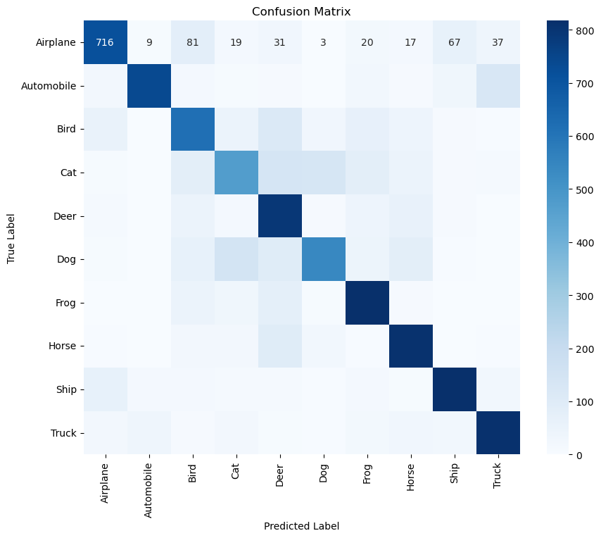

```python
import seaborn as sns
import matplotlib.pyplot as plt

plt.figure(figsize=(10, 8))
sns.heatmap(conf_matrix, annot=True, fmt='d', cmap='Blues', xticklabels=[
    'Airplane', 'Automobile', 'Bird', 'Cat', 'Deer',
    'Dog', 'Frog', 'Horse', 'Ship', 'Truck'
], yticklabels=[
    'Airplane', 'Automobile', 'Bird', 'Cat', 'Deer',
    'Dog', 'Frog', 'Horse', 'Ship', 'Truck'
])
plt.ylabel('True Label')
plt.xlabel('Predicted Label')
plt.title('Confusion Matrix')
plt.show()
```

**General Observations**

**Strong Performance:**

Classes like airplanes, ships, and automobiles are classified well, with a high number of correct predictions and fewer misclassifications.

**Weak Performance:**

Classes like birds, cats, and dogs have more significant misclassifications, indicating room for improvement in distinguishing features.

### Results Visualization

[figure not shown]

[figure not shown]

```python
import matplotlib.pyplot as plt

# Extract accuracy and loss from the history object
train_accuracy = history.history['accuracy']
val_accuracy = history.history['val_accuracy']
train_loss = history.history['loss']
val_loss = history.history['val_loss']

# Plot training and validation accuracy
plt.figure(figsize=(12, 6))
plt.plot(train_accuracy, label='Training Accuracy', marker='o')
plt.plot(val_accuracy, label='Validation Accuracy', marker='o')
plt.title('Training and Validation Accuracy')
plt.xlabel('Epochs')
plt.ylabel('Accuracy')
plt.legend()
plt.grid()
plt.show()

# Plot training and validation loss
plt.figure(figsize=(12, 6))
plt.plot(train_loss, label='Training Loss', marker='o')
plt.plot(val_loss, label='Validation Loss', marker='o')
plt.title('Training and Validation Loss')
plt.xlabel('Epochs')
plt.ylabel('Loss')
plt.legend()
plt.grid()
plt.show()
```

**Analysing the plots**

**Accuracy Plot:**

- The training accuracy steadily increases over epochs, reaching ~75%.

The validation accuracy also improves but starts to plateau around ~70%, with no significant divergence from the training accuracy

**Analysis:** Since the validation accuracy does not significantly drop or stagnate while the training accuracy increases, overfitting is not yet evident. However, the gap between training and validation accuracy might widen with further training, leading to overfitting

**Loss Plot:**

- The training loss decreases steadily.
- The validation loss also decreases but starts to plateau around epoch 7–8 and remains nearly constant afterward.

**Analysis:**

- The validation loss is close to the training loss, which suggests that the model is still generalizing well.
- There’s no sharp increase in validation loss, which is a common indicator of overfitting.

### 1.1.8 Finetunning and optimisation

From my plots(the loss plot), i see that there is an overfitting so i will use the Early stopping method to reduce the overfitting.

**Early Stopping:**

It Prevent overfitting by stopping training when validation loss stops improving:a.

```python
#implementing early stopping
from tensorflow.keras.callbacks import EarlyStopping

early_stopping = EarlyStopping(monitor='val_loss', patience=5, restore_best_weights=True)

history = model.fit(x_train, y_train, validation_data=(x_test, y_test), epochs=50, callbacks=[early_stopping])
```

```
1563/1563 ━━━━━━━━━━━━━━━━━━━━ 52s 32ms/step - accuracy: 0.5671 - loss: 1.2300 - val_accuracy: 0.6465 - val_loss: 1.0232
1563/1563 ━━━━━━━━━━━━━━━━━━━━ 49s 31ms/step - accuracy: 0.5969 - loss: 1.1475 - val_accuracy: 0.6650 - val_loss: 0.9824
1563/1563 ━━━━━━━━━━━━━━━━━━━━ 51s 33ms/step - accuracy: 0.6189 - loss: 1.0863 - val_accuracy: 0.6824 - val_loss: 0.9305
1563/1563 ━━━━━━━━━━━━━━━━━━━━ 51s 33ms/step - accuracy: 0.6324 - loss: 1.0489 - val_accuracy: 0.6739 - val_loss: 0.9377
1563/1563 ━━━━━━━━━━━━━━━━━━━━ 51s 33ms/step - accuracy: 0.6416 - loss: 1.0190 - val_accuracy: 0.6993 - val_loss: 0.8730
1563/1563 ━━━━━━━━━━━━━━━━━━━━ 52s 33ms/step - accuracy: 0.6501 - loss: 1.0029 - val_accuracy: 0.6988 - val_loss: 0.8800
1563/1563 ━━━━━━━━━━━━━━━━━━━━ 79s 31ms/step - accuracy: 0.6608 - loss: 0.9705 - val_accuracy: 0.7064 - val_loss: 0.8427
1563/1563 ━━━━━━━━━━━━━━━━━━━━ 49s 31ms/step - accuracy: 0.6676 - loss: 0.9543 - val_accuracy: 0.7114 - val_loss: 0.8409
1563/1563 ━━━━━━━━━━━━━━━━━━━━ 50s 32ms/step - accuracy: 0.6719 - loss: 0.9379 - val_accuracy: 0.6954 - val_loss: 0.8759
1563/1563 ━━━━━━━━━━━━━━━━━━━━ 82s 32ms/step - accuracy: 0.6780 - loss: 0.9135 - val_accuracy: 0.7132 - val_loss: 0.8424
1563/1563 ━━━━━━━━━━━━━━━━━━━━ 54s 34ms/step - accuracy: 0.6792 - loss: 0.9101 - val_accuracy: 0.7132 - val_loss: 0.8329
1563/1563 ━━━━━━━━━━━━━━━━━━━━ 50s 32ms/step - accuracy: 0.6864 - loss: 0.8958 - val_accuracy: 0.7151 - val_loss: 0.8348
1563/1563 ━━━━━━━━━━━━━━━━━━━━ 50s 32ms/step - accuracy: 0.6914 - loss: 0.8757 - val_accuracy: 0.7131 - val_loss: 0.8216
1563/1563 ━━━━━━━━━━━━━━━━━━━━ 50s 32ms/step - accuracy: 0.6908 - loss: 0.8704 - val_accuracy: 0.7208 - val_loss: 0.7965
1563/1563 ━━━━━━━━━━━━━━━━━━━━ 49s 31ms/step - accuracy: 0.6992 - loss: 0.8529 - val_accuracy: 0.7260 - val_loss: 0.7876
1563/1563 ━━━━━━━━━━━━━━━━━━━━ 51s 32ms/step - accuracy: 0.7047 - loss: 0.8445 - val_accuracy: 0.7284 - val_loss: 0.7969
1563/1563 ━━━━━━━━━━━━━━━━━━━━ 49s 31ms/step - accuracy: 0.7014 - loss: 0.8366 - val_accuracy: 0.7277 - val_loss: 0.7930
1563/1563 ━━━━━━━━━━━━━━━━━━━━ 50s 32ms/step - accuracy: 0.7058 - loss: 0.8316 - val_accuracy: 0.7178 - val_loss: 0.8231
1563/1563 ━━━━━━━━━━━━━━━━━━━━ 49s 32ms/step - accuracy: 0.7060 - loss: 0.8342 - val_accuracy: 0.7366 - val_loss: 0.7735
1563/1563 ━━━━━━━━━━━━━━━━━━━━ 50s 32ms/step - accuracy: 0.7117 - loss: 0.8213 - val_accuracy: 0.7289 - val_loss: 0.8044
1563/1563 ━━━━━━━━━━━━━━━━━━━━ 50s 32ms/step - accuracy: 0.7121 - loss: 0.8193 - val_accuracy: 0.7299 - val_loss: 0.7963
1563/1563 ━━━━━━━━━━━━━━━━━━━━ 50s 32ms/step - accuracy: 0.7094 - loss: 0.8192 - val_accuracy: 0.7272 - val_loss: 0.7936
1563/1563 ━━━━━━━━━━━━━━━━━━━━ 50s 32ms/step - accuracy: 0.7200 - loss: 0.8025 - val_accuracy: 0.7398 - val_loss: 0.7752
1563/1563 ━━━━━━━━━━━━━━━━━━━━ 84s 33ms/step - accuracy: 0.7214 - loss: 0.7887 - val_accuracy: 0.7376 - val_loss: 0.7679
1563/1563 ━━━━━━━━━━━━━━━━━━━━ 84s 35ms/step - accuracy: 0.7153 - loss: 0.7973 - val_accuracy: 0.7400 - val_loss: 0.7621
1563/1563 ━━━━━━━━━━━━━━━━━━━━ 53s 34ms/step - accuracy: 0.7174 - loss: 0.7876 - val_accuracy: 0.7395 - val_loss: 0.7631
1563/1563 ━━━━━━━━━━━━━━━━━━━━ 80s 32ms/step - accuracy: 0.7214 - loss: 0.7851 - val_accuracy: 0.7389 - val_loss: 0.7767
1563/1563 ━━━━━━━━━━━━━━━━━━━━ 53s 34ms/step - accuracy: 0.7245 - loss: 0.7817 - val_accuracy: 0.7409 - val_loss: 0.7548
1563/1563 ━━━━━━━━━━━━━━━━━━━━ 82s 34ms/step - accuracy: 0.7279 - loss: 0.7692 - val_accuracy: 0.7424 - val_loss: 0.7584
1563/1563 ━━━━━━━━━━━━━━━━━━━━ 81s 33ms/step - accuracy: 0.7301 - loss: 0.7659 - val_accuracy: 0.7413 - val_loss: 0.7668
1563/1563 ━━━━━━━━━━━━━━━━━━━━ 51s 33ms/step - accuracy: 0.7299 - loss: 0.7670 - val_accuracy: 0.7331 - val_loss: 0.7757
1563/1563 ━━━━━━━━━━━━━━━━━━━━ 82s 33ms/step - accuracy: 0.7307 - loss: 0.7579 - val_accuracy: 0.7402 - val_loss: 0.7663
1563/1563 ━━━━━━━━━━━━━━━━━━━━ 51s 33ms/step - accuracy: 0.7310 - loss: 0.7589 - val_accuracy: 0.7368 - val_loss: 0.7720
```

```python
model.evaluate(x_test,y_test)
```

```
313/313 ━━━━━━━━━━━━━━━━━━━━ 3s 10ms/step - accuracy: 0.7514 - loss: 0.7452
```

```
[0.7464827299118042, 0.7501000165939331]
```

Our model performed even better at 75%

### Monitor the Loss Curves again

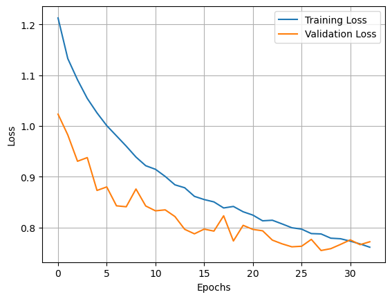

```python
import matplotlib.pyplot as plt

plt.plot(history.history['loss'], label='Training Loss')
plt.plot(history.history['val_loss'], label='Validation Loss')
plt.xlabel('Epochs')
plt.ylabel('Loss')
plt.legend()
plt.grid()
plt.show()
```

### Make predictions

```
313/313 ━━━━━━━━━━━━━━━━━━━━ 4s 11ms/step
```

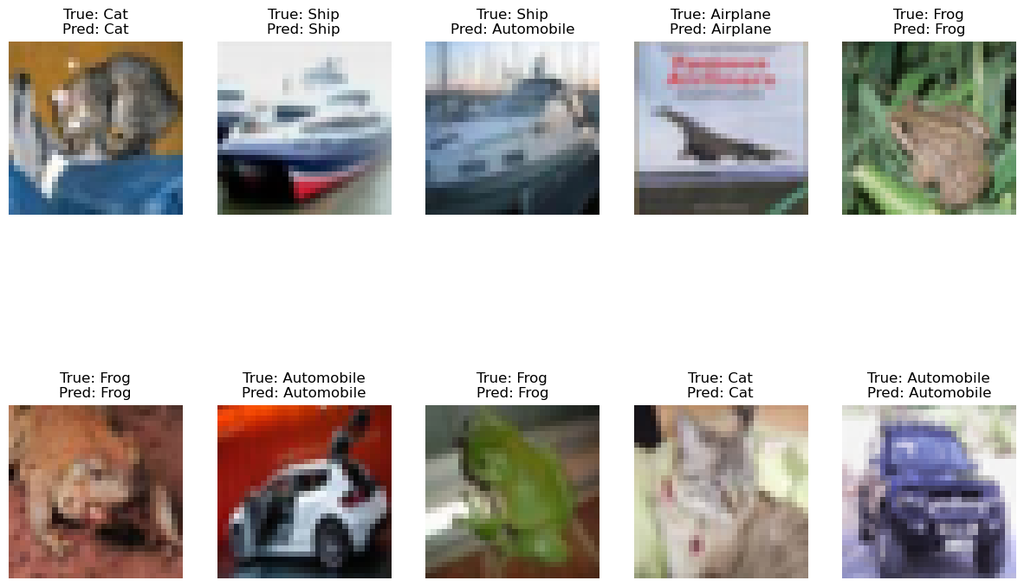

```python
# Load CIFAR-10 class names
class_names = ['Airplane', 'Automobile', 'Bird', 'Cat', 'Deer', 'Dog', 'Frog', 'Horse', 'Ship', 'Truck']

# Make predictions on the test set
predictions = model.predict(x_test)

# Convert predictions to class indices
predicted_classes = np.argmax(predictions, axis=1)  # Get the index of the highest probability
true_classes = np.argmax(y_test, axis=1)  # For one-hot encoded labels
# If y_test is sparse (integer labels), skip np.argmax

# Define a function to visualize predictions
def plot_predictions(x, y_true, y_pred, class_names, num_samples=10):
    plt.figure(figsize=(15, 10))
    for i in range(num_samples):
        plt.subplot(2, 5, i + 1)
        plt.imshow(x[i])
        plt.axis('off')
        plt.title(f"True: {class_names[y_true[i]]}\nPred: {class_names[y_pred[i]]}")
    plt.show()

# Visualize predictions on the first 10 test samples
plot_predictions(x_test, true_classes, predicted_classes, class_names, num_samples=10)
```

**Predict for a Single Image** If you want to predict for a single image:

```
1/1 ━━━━━━━━━━━━━━━━━━━━ 0s 58ms/step
```

[figure not shown]

```python
# Function to display image, true label, and predicted label
def show_prediction(model, image, true_label):
    # Expand dimensions of the image (if necessary) to match model input shape
    image_expanded = np.expand_dims(image, axis=0)

    # Predict the class probabilities
    predictions = model.predict(image_expanded)

    # Get the predicted class index
    predicted_class = np.argmax(predictions)

    # Display the image
    plt.imshow(image)
    plt.axis('off')

    # Show true and predicted labels
    plt.title(f"True: {class_labels[true_label]}, Predicted: {class_labels[predicted_class]}")
    plt.show()

# Example Usage
# Use an image and its corresponding true label from your dataset (e.g., x_test, y_test)
index = 0  # Replace with the desired index
show_prediction(model, x_test[index], y_test[index].argmax())
```

```
1/1 ━━━━━━━━━━━━━━━━━━━━ 0s 60ms/step
```

[figure not shown]

```python
index = 8  # Replace with the desired index
show_prediction(model, x_test[index], y_test[index].argmax())
```

## Conclusion

- CNNs are powerful for image classification tasks.

Overfitting can be effectively managed using regularization techniques(Dropout or L2 regularisation),Early stopping or Data Augmentation

We used the Early stopping technique to finetune our model during this projec

Validation metrics and visualizations are key to model evaluation.

# Transfer Learning

After making predictions, we went further to implement transfer learning on our model using the following steps:

- Use a pre-trained model as the feature extractor.
- Freeze some or all layers of the pre-trained model.
- Add custom layers for your specific task (e.g., CIFAR-10 classification).
- Fine-tune the model.

## Load Pre-Trained Model (VGG16 as an Example) and Build the Transfer Learning Model

```python
from tensorflow.keras.applications import VGG16  # Import VGG16 model


# Load the VGG16 model pre-trained on ImageNet, excluding the top layers
base_model = VGG16(weights='imagenet', include_top=False, input_shape=(32, 32, 3))

# Freeze the base model layers to prevent them from being updated during training
base_model.trainable = False

# Add custom layers on top of the base model
model = Sequential([
    base_model,
    Flatten(),
    Dense(256, activation='relu'),
    Dropout(0.5),
    Dense(10, activation='softmax')  # Output layer for 10 classes
])

# Compile the model
model.compile(optimizer='adam', loss='categorical_crossentropy', metrics=['accuracy'])

# Print the summary of the transfer learning model
model.summary()
```

```
Model: "sequential_3"
```

```
┏━━━━━━━━━━━━━━━━━━━━━━━━━━━━━━━━━━━━━━┳━━━━━━━━━━━━━━━━━━━━━━━━━━━━━┳━━━━━━━━━━━━━━━━━┓
┃ Layer (type)                         ┃ Output Shape                ┃         Param # ┃
┡━━━━━━━━━━━━━━━━━━━━━━━━━━━━━━━━━━━━━━╇━━━━━━━━━━━━━━━━━━━━━━━━━━━━━╇━━━━━━━━━━━━━━━━━┩
│ vgg16 (Functional)                   │ (None, 1, 1, 512)           │      14,714,688 │
├──────────────────────────────────────┼─────────────────────────────┼─────────────────┤
│ flatten_3 (Flatten)                  │ (None, 512)                 │               0 │
├──────────────────────────────────────┼─────────────────────────────┼─────────────────┤
│ dense_6 (Dense)                      │ (None, 256)                 │         131,328 │
├──────────────────────────────────────┼─────────────────────────────┼─────────────────┤
│ dropout_4 (Dropout)                  │ (None, 256)                 │               0 │
├──────────────────────────────────────┼─────────────────────────────┼─────────────────┤
│ dense_7 (Dense)                      │ (None, 10)                  │           2,570 │
└──────────────────────────────────────┴─────────────────────────────┴─────────────────┘
```

```
 Total params: 14,848,586 (56.64 MB)
```

```
 Trainable params: 133,898 (523.04 KB)
```

```
 Non-trainable params: 14,714,688 (56.13 MB)
```

## Train the Model

```python
# Train the model
history = model.fit(
    x_train, y_train,
    epochs=10,
    batch_size=64,
    validation_data=(x_test, y_test)
)

# Evaluate the model
test_loss, test_accuracy = model.evaluate(x_test, y_test)
print(f"Test Accuracy: {test_accuracy * 100:.2f}%")
```

```
782/782 ━━━━━━━━━━━━━━━━━━━━ 704s 894ms/step - accuracy: 0.3989 - loss: 1.7061 - val_accuracy: 0.5526 - val_loss: 1.2862
782/782 ━━━━━━━━━━━━━━━━━━━━ 726s 929ms/step - accuracy: 0.5402 - loss: 1.3111 - val_accuracy: 0.5759 - val_loss: 1.2228
782/782 ━━━━━━━━━━━━━━━━━━━━ 688s 880ms/step - accuracy: 0.5617 - loss: 1.2460 - val_accuracy: 0.5860 - val_loss: 1.1913
782/782 ━━━━━━━━━━━━━━━━━━━━ 663s 848ms/step - accuracy: 0.5770 - loss: 1.2062 - val_accuracy: 0.5883 - val_loss: 1.1721
782/782 ━━━━━━━━━━━━━━━━━━━━ 726s 929ms/step - accuracy: 0.5856 - loss: 1.1844 - val_accuracy: 0.5955 - val_loss: 1.1521
782/782 ━━━━━━━━━━━━━━━━━━━━ 769s 983ms/step - accuracy: 0.5947 - loss: 1.1615 - val_accuracy: 0.5993 - val_loss: 1.1502
782/782 ━━━━━━━━━━━━━━━━━━━━ 668s 854ms/step - accuracy: 0.6027 - loss: 1.1344 - val_accuracy: 0.6001 - val_loss: 1.1412
782/782 ━━━━━━━━━━━━━━━━━━━━ 1078s 1s/step - accuracy: 0.6046 - loss: 1.1297 - val_accuracy: 0.5992 - val_loss: 1.1323
782/782 ━━━━━━━━━━━━━━━━━━━━ 990s 1s/step - accuracy: 0.6089 - loss: 1.1116 - val_accuracy: 0.6032 - val_loss: 1.1238
782/782 ━━━━━━━━━━━━━━━━━━━━ 457s 516ms/step - accuracy: 0.6124 - loss: 1.1056 - val_accuracy: 0.6110 - val_loss: 1.1166
313/313 ━━━━━━━━━━━━━━━━━━━━ 79s 252ms/step - accuracy: 0.6168 - loss: 1.1075
Test Accuracy: 61.10%
```

The Transfer learning model shows 61% on both training and test model

## Fine-Tune the Model

Fine-tuning involves unfreezing some layers of the pre-trained model and training them with a lower learning rate.

```python
# Unfreeze the last few layers of the base model for fine-tuning
base_model.trainable = True
for layer in base_model.layers[:-4]:  # Freeze all layers except the last 4
    layer.trainable = False

# Compile the model with a lower learning rate for fine-tuning
model.compile(optimizer=tf.keras.optimizers.Adam(learning_rate=1e-5),
              loss='categorical_crossentropy', metrics=['accuracy'])

# Fine-tune the model
history_fine = model.fit(
    x_train, y_train,
    epochs=10,
    batch_size=64,
    validation_data=(x_test, y_test)
)

# Evaluate the fine-tuned model
test_loss, test_accuracy = model.evaluate(x_test, y_test)
print(f"Fine-tuned Test Accuracy: {test_accuracy * 100:.2f}%")
```

```
782/782 ━━━━━━━━━━━━━━━━━━━━ 1515s 2s/step - accuracy: 0.6442 - loss: 1.0220 - val_accuracy: 0.6603 - val_loss: 0.9698
782/782 ━━━━━━━━━━━━━━━━━━━━ 4091s 5s/step - accuracy: 0.6913 - loss: 0.8727 - val_accuracy: 0.6837 - val_loss: 0.9113
782/782 ━━━━━━━━━━━━━━━━━━━━ 885s 1s/step - accuracy: 0.7266 - loss: 0.7804 - val_accuracy: 0.6932 - val_loss: 0.8953
782/782 ━━━━━━━━━━━━━━━━━━━━ 638s 816ms/step - accuracy: 0.7452 - loss: 0.7122 - val_accuracy: 0.7046 - val_loss: 0.8608
782/782 ━━━━━━━━━━━━━━━━━━━━ 1513s 2s/step - accuracy: 0.7696 - loss: 0.6520 - val_accuracy: 0.7108 - val_loss: 0.8435
782/782 ━━━━━━━━━━━━━━━━━━━━ 2774s 4s/step - accuracy: 0.7866 - loss: 0.5993 - val_accuracy: 0.7159 - val_loss: 0.8333
782/782 ━━━━━━━━━━━━━━━━━━━━ 764s 977ms/step - accuracy: 0.8018 - loss: 0.5576 - val_accuracy: 0.7244 - val_loss: 0.8287
782/782 ━━━━━━━━━━━━━━━━━━━━ 1338s 2s/step - accuracy: 0.8197 - loss: 0.5093 - val_accuracy: 0.7248 - val_loss: 0.8393
782/782 ━━━━━━━━━━━━━━━━━━━━ 669s 855ms/step - accuracy: 0.8341 - loss: 0.4645 - val_accuracy: 0.7292 - val_loss: 0.8263
782/782 ━━━━━━━━━━━━━━━━━━━━ 1625s 2s/step - accuracy: 0.8479 - loss: 0.4311 - val_accuracy: 0.7267 - val_loss: 0.8466
313/313 ━━━━━━━━━━━━━━━━━━━━ 73s 233ms/step - accuracy: 0.7290 - loss: 0.8400
Fine-tuned Test Accuracy: 72.67%
```

## Save and Use the Model

```python
model.save('my_model.keras')
```

## Conclusion

While the model demonstrates strong feature extraction capabilities, fine-tuning and data augmentation are necessary to further improve class-specific performance

With the proper optimizations, transfer learning can significantly outperform training a CNN from scratch, especially on small datasets like CIFAR-10.

# General Conclusion

From our observation, we preffer the CNN model to the transfer learning model because we got a better accuracy score on our CNN model(75%) as compared to the Transfer learning model (72%)

However, we think a better model with higher accuracy could be achieved by implementing advanced Architectures like by replacing VGG16 with modern models like

- **ResNet(Residual Networks):** Introduces skip connections for deeper networks.
- **EfficientNet:** Achieves better accuracy with fewer parameters
- **MobileNet:** Designed for efficiency on mobile and embedded devices.